# GBLUP and cross validation

Izel Fourie Sørensen

October 6, 2017

Here we show how to perform a GBLUP analyses and cross validation using the greml function in the qgg package. This involves estimating variance components with restricted maximum likelihood estimation (REML) in the training set and prediction using genomic best linear unbiased prediction (GBLUP) in the validation set. This will be illustrated on the “starvation resistance” phenotype available from the *Drosophila* Genetic Reference Panel (DGRP).

To perform a GBLUP analysis the following input data is essential.

1. $y$: vector of phenotype
2. $X$: design matrix for covariables
3. $W$: centered and scaled genotype matrix
4. $G$: genomic relationship matrix

This script includes the following steps for performing a GBLUP analysis and cross validation: 1) load and prepare data for GBLUP analysis, 2) restricted maximum likelihood (REML) analyses for estimating variance components, and 3) REML analyses and cross validation.

##### **1. Load and prepare data for GBLUP analysis**

```r
#library(devtools)
#install_github("psoerensen/qgg")
library(qgg)
```

**Load phenotype and co-variable data**

```r
load(file = "./phenotypes/starv_inv_wo.Rdata")
dim(starvIW)
```

```
## [1] 406  20
```

```r
head(starvIW)
```

```
##     L sex        y  In2Lt In2RNS In2RY1 In2RY2 In2RY3 In2RY4 In2RY5 In2RY6
## 1 100   M 49.28000 INV/ST     ST     ST     ST     ST     ST     ST     ST
## 2 101   M 47.20000 INV/ST     ST     ST     ST     ST     ST     ST     ST
## 3 105   M 51.04000     ST     ST     ST     ST     ST     ST     ST     ST
## 4 109   M 44.96000 INV/ST     ST     ST     ST     ST     ST     ST     ST
## 5 129   M 33.08475     ST     ST     ST     ST     ST     ST     ST     ST
## 6 136   M 63.04000     ST     ST     ST     ST     ST     ST     ST     ST
##   In2RY7  In3LP In3LM In3LY In3RP  In3RK In3RMo In3RC Wo
## 1     ST     ST    ST    ST    ST    INV     ST    ST  y
## 2     ST     ST    ST    ST    ST     ST     ST    ST  n
## 3     ST     ST    ST    ST    ST    INV     ST    ST  n
## 4     ST     ST    ST    ST    ST     ST     ST    ST  n
## 5     ST     ST    ST    ST    ST     ST     ST    ST  n
## 6     ST INV/ST    ST    ST    ST INV/ST     ST    ST  y
```

Create a vector of the starvation resistance phenotype, $y$.

```r
data <- starvIW
y <- data$y
```

Prepare the design matrix $X$ for the covariables. `fm` is the formula used for including relevant variables in the model in order to construct a design matrix.

```r
fm <- y ~  Wo +In2Lt + In2RNS + In3RP + In3RK + In3RMo
X <- model.matrix(fm, data=data)
dim(X)
```

```
## [1] 406  12
```

```r
X[1:5,]
```

```
##   (Intercept) Woy In2LtINV/ST In2LtST In2RNSINV/ST In2RNSST In3RPINV/ST
## 1           1   1           1       0            0        1           0
## 2           1   0           1       0            0        1           0
## 3           1   0           0       1            0        1           0
## 4           1   0           1       0            0        1           0
## 5           1   0           0       1            0        1           0
##   In3RPST In3RKINV/ST In3RKST In3RMoINV/ST In3RMoST
## 1       1           0       0            0        1
## 2       1           0       1            0        1
## 3       1           0       0            0        1
## 4       1           0       1            0        1
## 5       1           0       1            0        1
```

**Load centered and scaled genotype matrix $W$**

```r
load(file= "./genotypes/dgrp2_W2.Rdata")
dim(W)
```

```
## [1]     205 1725755
```

```r
W[1:5,1:5]
```

```
##       2L_5317    2L_5372    2L_5390    2L_5403    2L_5465
## 21 -0.2486289 -0.6646914  1.2122772 -0.4059216 -0.4007831
## 26 -0.2486289 -0.6646914 -0.8200699 -0.4059216 -0.4007831
## 28 -0.2486289 -0.6646914  1.2122772 -0.4059216 -0.4007831
## 31  4.0006648 -0.6646914 -0.8200699 -0.4059216 -0.4007831
## 32 -0.2486289 -0.6646914 -0.8200699 -0.4059216 -0.4007831
```

**Compute $G$ from $W$**

The additive genomic relationship matrix $G$ (VanRaden PM. 2008. J Dairy Sci. 91:4414-4423) is constructed using all genetic markers as follows: $G=WW'/m$, where $W$ is the centered and scaled genotype matrix, and $m$ is the total number of markers.

```r
L <- data$L
G <- computeG(W=W)
G <- G[L,L] # this ensures that row id's in G corresponds to row id's in data, there is male and female data for each line.
```

##### **2. Restricted maximum likelihood (REML) analyses**

**Behind the scenes of the greml function:**
REML analyses are used for estimating the variance components, $\sigma_{g}^2$ and $\sigma_{e}^2$ for the random effects in the linear mixed model:
$$y = Xb + Zg + e$$

where $y$ is the vector of phenotypic observations, $X$ and $Z$ are design matrices for the fixed and random effects, $b$ is a vector of fixed effects, $g$ is the vector of genomic values captured by all genetic markers, and $e$ is the vector of residuals. The random genomic values and the residuals were assumed to be independent normally distributed values described as follows: $g \sim N(0,G\sigma_g^2 )$ and $e \sim N(0,I\sigma_e^2)$. Thus, we assume that the observed phenotypes $y \sim N(Xb,V)$ where $V=ZGZ'\sigma_g^2+I\sigma_e^2$.

Here we predict the genetic value based on the phenotype observed in the whole study population:

$$\hat{g} = \hat\sigma_g^2GZ'{\hat{V}}^{-1}(y-X\hat{b})$$

The phenotype is predicted as:

$$\hat{y} = X\hat{b} + Z\hat{g}$$

The greml function returns a list structure that includes estimates of the fixed effects ($b$), random effects ($g$) and residual effects ($e$). Other values in the list is described in the greml help page.

```r
fitG <- greml(y=y, X=X, G=list(G), verbose = TRUE)
```

```
## [1] "Iteration:" "1"          "Theta:"     "6.50461"    "6.64356"
## [1] "Iteration:" "2"          "Theta:"     "12.20169"   "12.99585"
## [1] "Iteration:" "3"          "Theta:"     "21.50944"   "24.87665"
## [1] "Iteration:" "4"          "Theta:"     "33.69124"   "45.66366"
## [1] "Iteration:" "5"          "Theta:"     "42.78148"   "77.52281"
## [1] "Iteration:" "6"          "Theta:"     "40.09061"   "115.13605"
## [1] "Iteration:" "7"          "Theta:"     "30.90551"   "141.89381"
## [1] "Iteration:" "8"          "Theta:"     "27.72753"   "149.23911"
## [1] "Iteration:" "9"          "Theta:"     "27.61509"   "149.57631"
## [1] "Iteration:" "10"         "Theta:"     "27.61728"   "149.57512"
## [1] "Iteration:" "11"         "Theta:"     "27.61724"   "149.57514"
## [1] "Iteration:" "12"         "Theta:"     "27.61724"   "149.57514"
```

##### **3. REML analyses and cross validation**

Here we predict the genetic value based on the genomic relationship between the training and validation population:

$$\hat{g^v} = \hat\sigma_g^2G^{vt}Z'{\hat{V_t}}^{-1}(y_t-X_t\hat{b_t})$$
Where the genomic relationship matrix
$$G =
\left(\begin{array}{cc} G^{vv} & G^{vt}\\
G^{vt} & G^{tt} \end{array}
\right)$$

is partitioned according to relationships between the individuals in the training ($t$) data $G^{tt}$, between the individuals in the validation ($v$) data $G^{vv}$ and between the individuals in the training and validation data $G^{vt}$. Thus the total genomic predisposition is predicted using the estimated variance components ($\sigma_g^2$ and $\sigma_e^2$) in the training data. The right-most term, $(y_t-X_t\hat{b_t})$, constitutes the phenotypes corrected for fixed effects for the individuals in the training data. The inverse term $\hat{V}_t^{-1}$ is essentially the variance-covariance structure for the corrected phenotypes. These two terms multiplied together are the standardized and corrected phenotypes for the individuals in the training data, which are projected onto the total genetic covariance structure between the training and the validation data.

Variance components for the phenotype observed in the *training set* is estimated. Based on the estimated variance components, the phenotype in the *validation set* is predicted as:
$$\hat{y_v} = X_v\hat{b_t} + Z\hat{g}_v + e$$

Here 50 validation sets are created by randomly sampling 30 values from 1 - 406 (the length of $y$), and repeating this sampling 50 times. The validation sets are saved in the `validate` matrix. This matrix specifies the rows of the data used in the GREML analyses.

```r
n <- length(y)
validate <- replicate(50, sample(1:n, 30))
cvG <- greml(y = y, X = X, G = list(G=G), validate = validate)
```

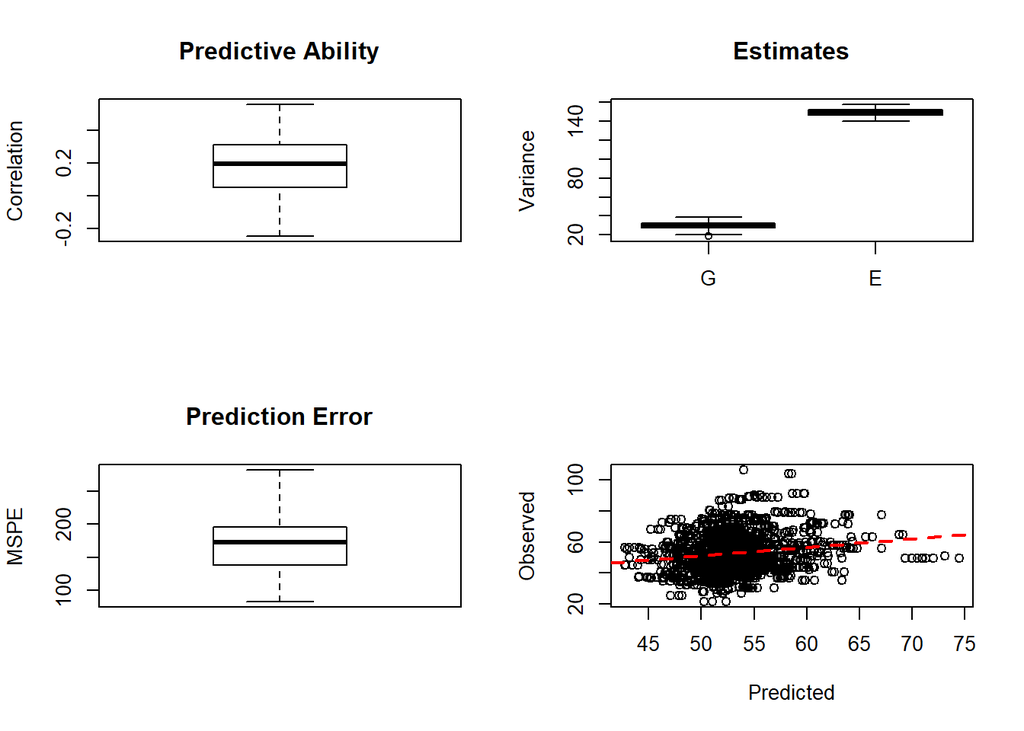

```r
head(cvG)
```

```
##         Corr          R2 Nagel R2 AUC intercept     slope     MSPE
## 1 0.14130625 0.019967455       NA  NA  27.50283 0.4410429 173.9427
## 2 0.24883888 0.061920787       NA  NA -29.88398 1.5626744 282.3655
## 3 0.07760932 0.006023206       NA  NA  40.59960 0.3219710 242.4885
## 4 0.53681456 0.288169867       NA  NA -48.14302 1.8986363 160.0739
## 5 0.03876244 0.001502527       NA  NA  43.75830 0.2000570 261.6888
## 6 0.12397264 0.015369215       NA  NA  40.72064 0.2598375 201.0792
##          G        E
## 1 27.28519 149.9187
## 2 24.19299 143.7974
## 3 27.77224 144.1871
## 4 28.10549 150.7439
## 5 28.79397 141.6941
## 6 30.23533 146.3126
```

**Output of the GREML cross validation analysis**

The output includes statistics that quantify the model’s predictive ability as assessed by regressing the observed phenotype against the predicted phenotype for the validation data set: $y = intercept + \hat{y} slope + e$

| Value |  | Description |
| --- | --- | --- |
| Corr |  | Correlation between the predicted and observed phenotypic value. Averaging the list of 50 correlations yields the predictive ability |
| R2 |  | $R^2$, proportion of the total variance that is explained by the GBLUP model |
| Nagel R2 |  | Nagelkerke’s $R$ |
| AUC |  | Area Under the ROC Curve |
| intercept |  | The y-axis intercept for the regression of $y$ unto $\hat{y}$ |
| slope |  | Slope for the regression of $y$ unto $\hat{y}$ |
| MSPE |  | mean squared prediction error = $\frac{1}{n_v}\sum_{i=1}^{n_v}({y_i - \hat{y_i})^2}$, $n_v$ = number of observations in validation set |
| G |  | Estimated variance component, $\hat\sigma_{g}^2$ |
| E |  | Estimated variance component, $\hat\sigma_{e}^2$ |

**Prepare data frame of results**

```r
cvGmean <- colMeans(cvG)

cvGsem <- apply(cvG, 2, function(x){sd(x)/sqrt(50)})

stat <- c("mean","sem")
results <- data.frame(stat,rbind(cvGmean,cvGsem))
results
```

```
##         stat       Corr          R2 Nagel.R2 AUC intercept      slope
## cvGmean mean 0.18509116 0.063738756       NA  NA 18.297025 0.64910250
## cvGsem   sem 0.02452821 0.009816746       NA  NA  4.765313 0.08970053
##               MSPE          G           E
## cvGmean 170.988995 29.2218944 148.9020897
## cvGsem    6.157207  0.6063692   0.6178014
```

**Heritability ($\hat{h^2}$)**

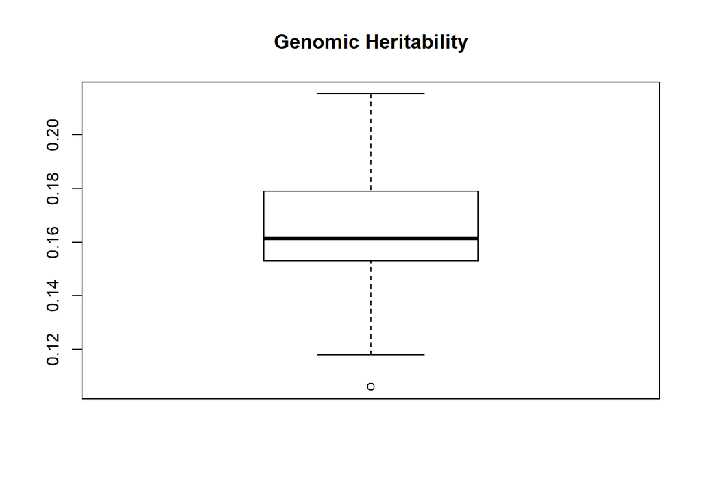

```r
h2fm <- cvG$G/(cvG$G+cvG$E)
boxplot(h2fm, main = "Genomic Heritability")
```

**Histogram of genetic values**

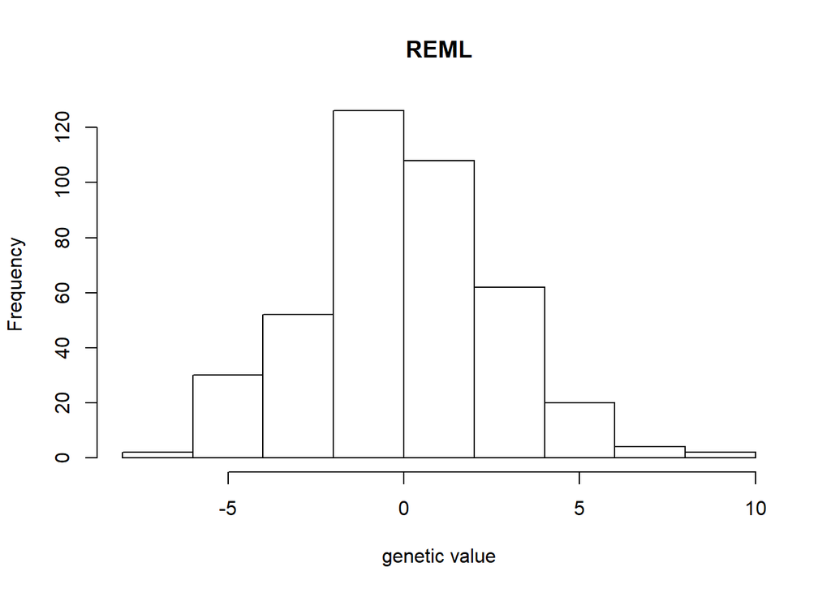

```r
hist(fitG$g, xlab = "genetic value", main = "REML")
```

**Histogram of phenotype**

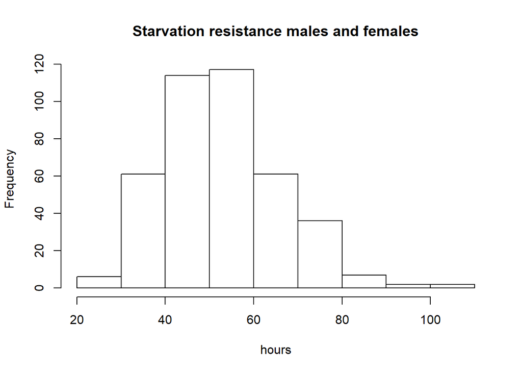

```r
hist(y, xlab = "hours", main = "Starvation resistance males and females")
```